# Risk Factor Analysis

## Outcome Variable

**Outcome Variable:** ever_stunted

## Predictor Variables

**Intervention Variable:** pers_wast

**Adjustment Set:**

unadjusted

## Stratifying Variables

The analysis was stratified on these variable(s):

- agecat
- studyid
- country

## Data Summary

| agecat | studyid | country | pers_wast | ever_stunted | n_cell | n |
| --- | --- | --- | --- | --- | --- | --- |
| 0-6 months | ki0047075b-MAL-ED | BANGLADESH | 0 | 0 | 210 | 263 |
| 0-6 months | ki0047075b-MAL-ED | BANGLADESH | 0 | 1 | 44 | 263 |
| 0-6 months | ki0047075b-MAL-ED | BANGLADESH | 1 | 0 | 7 | 263 |
| 0-6 months | ki0047075b-MAL-ED | BANGLADESH | 1 | 1 | 2 | 263 |
| 0-6 months | ki0047075b-MAL-ED | BRAZIL | 0 | 0 | 207 | 233 |
| 0-6 months | ki0047075b-MAL-ED | BRAZIL | 0 | 1 | 25 | 233 |
| 0-6 months | ki0047075b-MAL-ED | BRAZIL | 1 | 0 | 1 | 233 |
| 0-6 months | ki0047075b-MAL-ED | BRAZIL | 1 | 1 | 0 | 233 |
| 0-6 months | ki0047075b-MAL-ED | INDIA | 0 | 0 | 190 | 251 |
| 0-6 months | ki0047075b-MAL-ED | INDIA | 0 | 1 | 40 | 251 |
| 0-6 months | ki0047075b-MAL-ED | INDIA | 1 | 0 | 19 | 251 |
| 0-6 months | ki0047075b-MAL-ED | INDIA | 1 | 1 | 2 | 251 |
| 0-6 months | ki0047075b-MAL-ED | NEPAL | 0 | 0 | 207 | 240 |
| 0-6 months | ki0047075b-MAL-ED | NEPAL | 0 | 1 | 28 | 240 |
| 0-6 months | ki0047075b-MAL-ED | NEPAL | 1 | 0 | 5 | 240 |
| 0-6 months | ki0047075b-MAL-ED | NEPAL | 1 | 1 | 0 | 240 |
| 0-6 months | ki0047075b-MAL-ED | PERU | 0 | 0 | 266 | 302 |
| 0-6 months | ki0047075b-MAL-ED | PERU | 0 | 1 | 36 | 302 |
| 0-6 months | ki0047075b-MAL-ED | SOUTH AFRICA | 0 | 0 | 273 | 313 |
| 0-6 months | ki0047075b-MAL-ED | SOUTH AFRICA | 0 | 1 | 33 | 313 |
| 0-6 months | ki0047075b-MAL-ED | SOUTH AFRICA | 1 | 0 | 7 | 313 |
| 0-6 months | ki0047075b-MAL-ED | SOUTH AFRICA | 1 | 1 | 0 | 313 |
| 0-6 months | ki0047075b-MAL-ED | TANZANIA, UNITED REPUBLIC OF | 0 | 0 | 219 | 261 |
| 0-6 months | ki0047075b-MAL-ED | TANZANIA, UNITED REPUBLIC OF | 0 | 1 | 42 | 261 |
| 0-6 months | ki1000108-CMC-V-BCS-2002 | INDIA | 0 | 0 | 252 | 368 |
| 0-6 months | ki1000108-CMC-V-BCS-2002 | INDIA | 0 | 1 | 61 | 368 |
| 0-6 months | ki1000108-CMC-V-BCS-2002 | INDIA | 1 | 0 | 40 | 368 |
| 0-6 months | ki1000108-CMC-V-BCS-2002 | INDIA | 1 | 1 | 15 | 368 |
| 0-6 months | ki1000108-IRC | INDIA | 0 | 0 | 295 | 410 |
| 0-6 months | ki1000108-IRC | INDIA | 0 | 1 | 44 | 410 |

[output cut: 180 more lines]

The following strata were considered:

- agecat: 0-24 months, studyid: ki0047075b-MAL-ED, country: BANGLADESH
- agecat: 0-24 months, studyid: ki0047075b-MAL-ED, country: BRAZIL
- agecat: 0-24 months, studyid: ki0047075b-MAL-ED, country: INDIA
- agecat: 0-24 months, studyid: ki0047075b-MAL-ED, country: NEPAL
- agecat: 0-24 months, studyid: ki0047075b-MAL-ED, country: PERU
- agecat: 0-24 months, studyid: ki0047075b-MAL-ED, country: SOUTH AFRICA
- agecat: 0-24 months, studyid: ki0047075b-MAL-ED, country: TANZANIA, UNITED REPUBLIC OF
- agecat: 0-24 months, studyid: ki1000108-CMC-V-BCS-2002, country: INDIA
- agecat: 0-24 months, studyid: ki1000108-IRC, country: INDIA
- agecat: 0-24 months, studyid: ki1000109-EE, country: PAKISTAN
- agecat: 0-24 months, studyid: ki1000109-ResPak, country: PAKISTAN
- agecat: 0-24 months, studyid: ki1017093b-PROVIDE, country: BANGLADESH
- agecat: 0-24 months, studyid: ki1066203-TanzaniaChild2, country: TANZANIA, UNITED REPUBLIC OF
- agecat: 0-24 months, studyid: ki1101329-Keneba, country: GAMBIA
- agecat: 0-24 months, studyid: ki1112895-Guatemala BSC, country: GUATEMALA
- agecat: 0-24 months, studyid: ki1113344-GMS-Nepal, country: NEPAL
- agecat: 0-24 months, studyid: ki1114097-CMIN, country: BANGLADESH
- agecat: 0-24 months, studyid: ki1114097-CMIN, country: PERU
- agecat: 0-24 months, studyid: ki1114097-CONTENT, country: PERU
- agecat: 0-6 months, studyid: ki0047075b-MAL-ED, country: BANGLADESH
- agecat: 0-6 months, studyid: ki0047075b-MAL-ED, country: BRAZIL
- agecat: 0-6 months, studyid: ki0047075b-MAL-ED, country: INDIA
- agecat: 0-6 months, studyid: ki0047075b-MAL-ED, country: NEPAL
- agecat: 0-6 months, studyid: ki0047075b-MAL-ED, country: PERU
- agecat: 0-6 months, studyid: ki0047075b-MAL-ED, country: SOUTH AFRICA
- agecat: 0-6 months, studyid: ki0047075b-MAL-ED, country: TANZANIA, UNITED REPUBLIC OF
- agecat: 0-6 months, studyid: ki1000108-CMC-V-BCS-2002, country: INDIA
- agecat: 0-6 months, studyid: ki1000108-IRC, country: INDIA
- agecat: 0-6 months, studyid: ki1000109-EE, country: PAKISTAN
- agecat: 0-6 months, studyid: ki1000109-ResPak, country: PAKISTAN
- agecat: 0-6 months, studyid: ki1017093b-PROVIDE, country: BANGLADESH
- agecat: 0-6 months, studyid: ki1066203-TanzaniaChild2, country: TANZANIA, UNITED REPUBLIC OF
- agecat: 0-6 months, studyid: ki1101329-Keneba, country: GAMBIA
- agecat: 0-6 months, studyid: ki1112895-Guatemala BSC, country: GUATEMALA
- agecat: 0-6 months, studyid: ki1113344-GMS-Nepal, country: NEPAL
- agecat: 0-6 months, studyid: ki1114097-CMIN, country: BANGLADESH
- agecat: 0-6 months, studyid: ki1114097-CMIN, country: PERU
- agecat: 0-6 months, studyid: ki1114097-CONTENT, country: PERU
- agecat: 6-24 months, studyid: ki0047075b-MAL-ED, country: BANGLADESH
- agecat: 6-24 months, studyid: ki0047075b-MAL-ED, country: BRAZIL
- agecat: 6-24 months, studyid: ki0047075b-MAL-ED, country: INDIA
- agecat: 6-24 months, studyid: ki0047075b-MAL-ED, country: NEPAL
- agecat: 6-24 months, studyid: ki0047075b-MAL-ED, country: PERU
- agecat: 6-24 months, studyid: ki0047075b-MAL-ED, country: SOUTH AFRICA
- agecat: 6-24 months, studyid: ki0047075b-MAL-ED, country: TANZANIA, UNITED REPUBLIC OF
- agecat: 6-24 months, studyid: ki1000108-CMC-V-BCS-2002, country: INDIA
- agecat: 6-24 months, studyid: ki1000108-IRC, country: INDIA
- agecat: 6-24 months, studyid: ki1000109-EE, country: PAKISTAN
- agecat: 6-24 months, studyid: ki1000109-ResPak, country: PAKISTAN
- agecat: 6-24 months, studyid: ki1017093b-PROVIDE, country: BANGLADESH
- agecat: 6-24 months, studyid: ki1066203-TanzaniaChild2, country: TANZANIA, UNITED REPUBLIC OF
- agecat: 6-24 months, studyid: ki1101329-Keneba, country: GAMBIA
- agecat: 6-24 months, studyid: ki1112895-Guatemala BSC, country: GUATEMALA
- agecat: 6-24 months, studyid: ki1113344-GMS-Nepal, country: NEPAL
- agecat: 6-24 months, studyid: ki1114097-CMIN, country: BANGLADESH
- agecat: 6-24 months, studyid: ki1114097-CMIN, country: PERU
- agecat: 6-24 months, studyid: ki1114097-CONTENT, country: PERU

### Dropped Strata

Some strata were dropped due to rare outcomes:

- agecat: 0-6 months, studyid: ki0047075b-MAL-ED, country: BANGLADESH
- agecat: 0-6 months, studyid: ki0047075b-MAL-ED, country: BRAZIL
- agecat: 0-6 months, studyid: ki0047075b-MAL-ED, country: INDIA
- agecat: 0-6 months, studyid: ki0047075b-MAL-ED, country: NEPAL
- agecat: 0-6 months, studyid: ki0047075b-MAL-ED, country: SOUTH AFRICA
- agecat: 0-6 months, studyid: ki1017093b-PROVIDE, country: BANGLADESH
- agecat: 0-6 months, studyid: ki1066203-TanzaniaChild2, country: TANZANIA, UNITED REPUBLIC OF
- agecat: 0-6 months, studyid: ki1112895-Guatemala BSC, country: GUATEMALA
- agecat: 0-6 months, studyid: ki1114097-CMIN, country: PERU
- agecat: 6-24 months, studyid: ki0047075b-MAL-ED, country: BANGLADESH
- agecat: 6-24 months, studyid: ki0047075b-MAL-ED, country: BRAZIL
- agecat: 6-24 months, studyid: ki0047075b-MAL-ED, country: INDIA
- agecat: 6-24 months, studyid: ki0047075b-MAL-ED, country: NEPAL
- agecat: 6-24 months, studyid: ki0047075b-MAL-ED, country: SOUTH AFRICA
- agecat: 6-24 months, studyid: ki1000109-EE, country: PAKISTAN
- agecat: 6-24 months, studyid: ki1017093b-PROVIDE, country: BANGLADESH
- agecat: 6-24 months, studyid: ki1066203-TanzaniaChild2, country: TANZANIA, UNITED REPUBLIC OF
- agecat: 6-24 months, studyid: ki1112895-Guatemala BSC, country: GUATEMALA
- agecat: 6-24 months, studyid: ki1114097-CMIN, country: BANGLADESH
- agecat: 6-24 months, studyid: ki1114097-CMIN, country: PERU
- agecat: 0-24 months, studyid: ki0047075b-MAL-ED, country: BANGLADESH
- agecat: 0-24 months, studyid: ki0047075b-MAL-ED, country: BRAZIL
- agecat: 0-24 months, studyid: ki0047075b-MAL-ED, country: NEPAL
- agecat: 0-24 months, studyid: ki0047075b-MAL-ED, country: SOUTH AFRICA
- agecat: 0-24 months, studyid: ki1000108-CMC-V-BCS-2002, country: INDIA
- agecat: 0-24 months, studyid: ki1000109-EE, country: PAKISTAN
- agecat: 0-24 months, studyid: ki1112895-Guatemala BSC, country: GUATEMALA
- agecat: 0-24 months, studyid: ki1114097-CMIN, country: BANGLADESH

## Methods Detail

We’re interested in the causal parameters $E[Y_a]$ for all values of $a \in \mathcal{A}$. These parameters represent the mean outcome if, possibly contrary to fact, we intervened to set all units to have $A=a$. Under the randomization and positivity assumptions, these are identified by the statistical parameters $\psi_a=E_W[E_{Y|A,W}(Y|A=a,W)]$. In addition, we’re interested in the mean of $Y$, $E[Y]$ under no intervention (the observed mean). We will estimate these parameters by using SuperLearner to fit the relevant likelihood factors – $E_{Y|A,W}(Y|A=a,W)$ and $p(A=a|W)$, and then updating our likelihood fit using a joint TMLE.

For unadjusted analyses ($W=\{\}$), initial likelihoods were estimated using Lrnr_glm to estimate the simple $E(Y|A)$ and Lrnr_mean to estimate $p(A)$. For adjusted analyses, a small library containing Lrnr_glmnet, Lrnr_xgboost, and Lrnr_mean was used.

Having estimated these parameters, we will then use the delta method to estimate relative risks and attributable risks relative to a prespecified baseline level of $A$.

[output not shown]

# Results Detail

## Results Plots

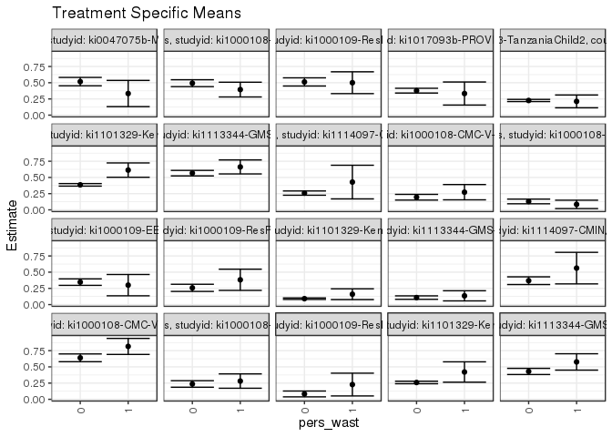

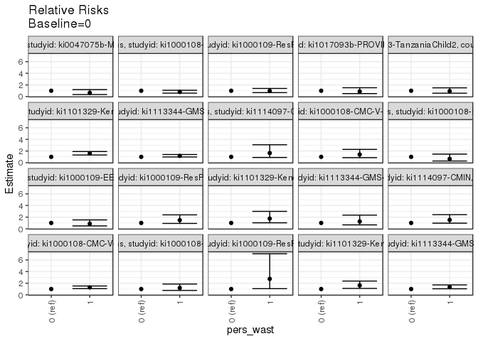

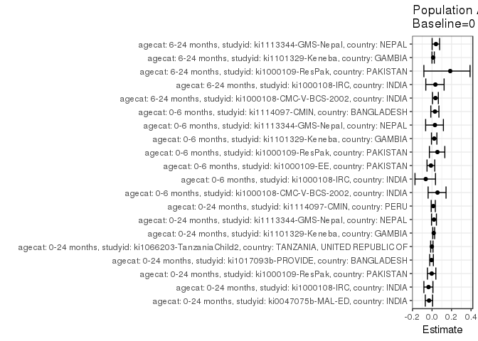

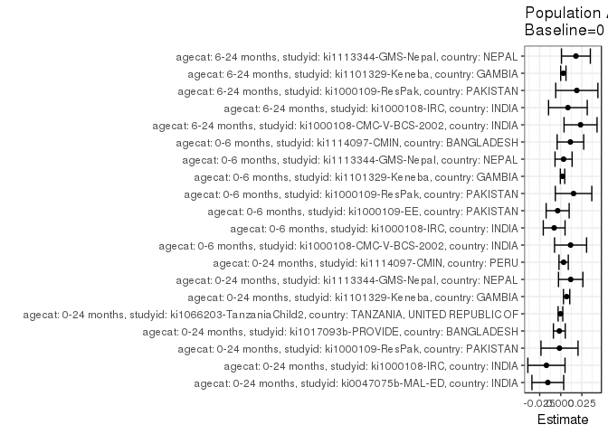

## Results Table

### Parameter: TSM

| agecat | studyid | country | intervention_level | baseline_level | estimate | ci_lower | ci_upper |
| --- | --- | --- | --- | --- | --- | --- | --- |
| 0-24 months | ki0047075b-MAL-ED | INDIA | 0 | NA | 0.5173913 | 0.4526833 | 0.5820993 |
| 0-24 months | ki0047075b-MAL-ED | INDIA | 1 | NA | 0.3333333 | 0.1313112 | 0.5353555 |
| 0-24 months | ki1000108-IRC | INDIA | 0 | NA | 0.4926254 | 0.4393408 | 0.5459099 |
| 0-24 months | ki1000108-IRC | INDIA | 1 | NA | 0.3943662 | 0.2805500 | 0.5081824 |
| 0-24 months | ki1000109-ResPak | PAKISTAN | 0 | NA | 0.5122951 | 0.4494640 | 0.5751261 |
| 0-24 months | ki1000109-ResPak | PAKISTAN | 1 | NA | 0.5000000 | 0.3316314 | 0.6683686 |
| 0-24 months | ki1017093b-PROVIDE | BANGLADESH | 0 | NA | 0.3774146 | 0.3407658 | 0.4140634 |
| 0-24 months | ki1017093b-PROVIDE | BANGLADESH | 1 | NA | 0.3333333 | 0.1553946 | 0.5112720 |
| 0-24 months | ki1066203-TanzaniaChild2 | TANZANIA, UNITED REPUBLIC OF | 0 | NA | 0.2261803 | 0.2091897 | 0.2431708 |
| 0-24 months | ki1066203-TanzaniaChild2 | TANZANIA, UNITED REPUBLIC OF | 1 | NA | 0.2121212 | 0.1134732 | 0.3107693 |
| 0-24 months | ki1101329-Keneba | GAMBIA | 0 | NA | 0.3859355 | 0.3664105 | 0.4054606 |
| 0-24 months | ki1101329-Keneba | GAMBIA | 1 | NA | 0.6133333 | 0.5030976 | 0.7235690 |
| 0-24 months | ki1113344-GMS-Nepal | NEPAL | 0 | NA | 0.5662879 | 0.5239809 | 0.6085948 |
| 0-24 months | ki1113344-GMS-Nepal | NEPAL | 1 | NA | 0.6621622 | 0.5543098 | 0.7700145 |
| 0-24 months | ki1114097-CMIN | PERU | 0 | NA | 0.2583942 | 0.2255890 | 0.2911993 |
| 0-24 months | ki1114097-CMIN | PERU | 1 | NA | 0.4285714 | 0.1691609 | 0.6879819 |
| 0-6 months | ki1000108-CMC-V-BCS-2002 | INDIA | 0 | NA | 0.1948882 | 0.1509454 | 0.2388310 |
| 0-6 months | ki1000108-CMC-V-BCS-2002 | INDIA | 1 | NA | 0.2727273 | 0.1548662 | 0.3905884 |
| 0-6 months | ki1000108-IRC | INDIA | 0 | NA | 0.1297935 | 0.0939743 | 0.1656127 |
| 0-6 months | ki1000108-IRC | INDIA | 1 | NA | 0.0845070 | 0.0197297 | 0.1492844 |
| 0-6 months | ki1000109-EE | PAKISTAN | 0 | NA | 0.3467049 | 0.2967079 | 0.3967019 |
| 0-6 months | ki1000109-EE | PAKISTAN | 1 | NA | 0.3000000 | 0.1358009 | 0.4641991 |
| 0-6 months | ki1000109-ResPak | PAKISTAN | 0 | NA | 0.2581967 | 0.2031850 | 0.3132085 |
| 0-6 months | ki1000109-ResPak | PAKISTAN | 1 | NA | 0.3823529 | 0.2187114 | 0.5459945 |
| 0-6 months | ki1101329-Keneba | GAMBIA | 0 | NA | 0.0912516 | 0.0797019 | 0.1028013 |
| 0-6 months | ki1101329-Keneba | GAMBIA | 1 | NA | 0.1600000 | 0.0770139 | 0.2429861 |
| 0-6 months | ki1113344-GMS-Nepal | NEPAL | 0 | NA | 0.1079545 | 0.0814631 | 0.1344460 |
| 0-6 months | ki1113344-GMS-Nepal | NEPAL | 1 | NA | 0.1351351 | 0.0571788 | 0.2130915 |
| 0-6 months | ki1114097-CMIN | BANGLADESH | 0 | NA | 0.3686275 | 0.3093052 | 0.4279497 |
| 0-6 months | ki1114097-CMIN | BANGLADESH | 1 | NA | 0.5625000 | 0.3189763 | 0.8060237 |
| 6-24 months | ki1000108-CMC-V-BCS-2002 | INDIA | 0 | NA | 0.6396761 | 0.5796985 | 0.6996538 |
| 6-24 months | ki1000108-CMC-V-BCS-2002 | INDIA | 1 | NA | 0.8157895 | 0.6923182 | 0.9392607 |
| 6-24 months | ki1000108-IRC | INDIA | 0 | NA | 0.2363636 | 0.1860765 | 0.2866508 |
| 6-24 months | ki1000108-IRC | INDIA | 1 | NA | 0.2812500 | 0.1709349 | 0.3915651 |
| 6-24 months | ki1000109-ResPak | PAKISTAN | 0 | NA | 0.0827586 | 0.0377789 | 0.1277383 |
| 6-24 months | ki1000109-ResPak | PAKISTAN | 1 | NA | 0.2272727 | 0.0516310 | 0.4029145 |
| 6-24 months | ki1101329-Keneba | GAMBIA | 0 | NA | 0.2595033 | 0.2401558 | 0.2788508 |
| 6-24 months | ki1101329-Keneba | GAMBIA | 1 | NA | 0.4210526 | 0.2640337 | 0.5780716 |
| 6-24 months | ki1113344-GMS-Nepal | NEPAL | 0 | NA | 0.4299287 | 0.3825893 | 0.4772681 |
| 6-24 months | ki1113344-GMS-Nepal | NEPAL | 1 | NA | 0.5762712 | 0.4500500 | 0.7024924 |

### Parameter: E(Y)

| agecat | studyid | country | intervention_level | baseline_level | estimate | ci_lower | ci_upper |
| --- | --- | --- | --- | --- | --- | --- | --- |
| 0-24 months | ki0047075b-MAL-ED | INDIA | NA | NA | 0.5019920 | 0.4400130 | 0.5639710 |
| 0-24 months | ki1000108-IRC | INDIA | NA | NA | 0.4756098 | 0.4272105 | 0.5240091 |
| 0-24 months | ki1000109-ResPak | PAKISTAN | NA | NA | 0.5107914 | 0.4519237 | 0.5696591 |
| 0-24 months | ki1017093b-PROVIDE | BANGLADESH | NA | NA | 0.3757143 | 0.3398113 | 0.4116172 |
| 0-24 months | ki1066203-TanzaniaChild2 | TANZANIA, UNITED REPUBLIC OF | NA | NA | 0.2257930 | 0.2090482 | 0.2425378 |
| 0-24 months | ki1101329-Keneba | GAMBIA | NA | NA | 0.3928571 | 0.3735695 | 0.4121448 |
| 0-24 months | ki1113344-GMS-Nepal | NEPAL | NA | NA | 0.5780731 | 0.5385891 | 0.6175571 |
| 0-24 months | ki1114097-CMIN | PERU | NA | NA | 0.2618026 | 0.2291894 | 0.2944158 |
| 0-6 months | ki1000108-CMC-V-BCS-2002 | INDIA | NA | NA | 0.2065217 | 0.1651060 | 0.2479375 |
| 0-6 months | ki1000108-IRC | INDIA | NA | NA | 0.1219512 | 0.0902381 | 0.1536643 |
| 0-6 months | ki1000109-EE | PAKISTAN | NA | NA | 0.3430079 | 0.2951521 | 0.3908637 |
| 0-6 months | ki1000109-ResPak | PAKISTAN | NA | NA | 0.2733813 | 0.2208950 | 0.3258676 |
| 0-6 months | ki1101329-Keneba | GAMBIA | NA | NA | 0.0933442 | 0.0818552 | 0.1048331 |
| 0-6 months | ki1113344-GMS-Nepal | NEPAL | NA | NA | 0.1112957 | 0.0861520 | 0.1364394 |
| 0-6 months | ki1114097-CMIN | BANGLADESH | NA | NA | 0.3800738 | 0.3221749 | 0.4379727 |
| 6-24 months | ki1000108-CMC-V-BCS-2002 | INDIA | NA | NA | 0.6631579 | 0.6081898 | 0.7181260 |
| 6-24 months | ki1000108-IRC | INDIA | NA | NA | 0.2448378 | 0.1989973 | 0.2906782 |
| 6-24 months | ki1000109-ResPak | PAKISTAN | NA | NA | 0.1017964 | 0.0557975 | 0.1477953 |
| 6-24 months | ki1101329-Keneba | GAMBIA | NA | NA | 0.2625559 | 0.2433195 | 0.2817924 |
| 6-24 months | ki1113344-GMS-Nepal | NEPAL | NA | NA | 0.4479167 | 0.4033837 | 0.4924496 |

### Parameter: RR

| agecat | studyid | country | intervention_level | baseline_level | estimate | ci_lower | ci_upper |
| --- | --- | --- | --- | --- | --- | --- | --- |
| 0-24 months | ki0047075b-MAL-ED | INDIA | 0 | 0 | 1.0000000 | 1.0000000 | 1.000000 |
| 0-24 months | ki0047075b-MAL-ED | INDIA | 1 | 0 | 0.6442577 | 0.3469785 | 1.196236 |
| 0-24 months | ki1000108-IRC | INDIA | 0 | 0 | 1.0000000 | 1.0000000 | 1.000000 |
| 0-24 months | ki1000108-IRC | INDIA | 1 | 0 | 0.8005398 | 0.5882062 | 1.089523 |
| 0-24 months | ki1000109-ResPak | PAKISTAN | 0 | 0 | 1.0000000 | 1.0000000 | 1.000000 |
| 0-24 months | ki1000109-ResPak | PAKISTAN | 1 | 0 | 0.9760000 | 0.6820382 | 1.396661 |
| 0-24 months | ki1017093b-PROVIDE | BANGLADESH | 0 | 0 | 1.0000000 | 1.0000000 | 1.000000 |
| 0-24 months | ki1017093b-PROVIDE | BANGLADESH | 1 | 0 | 0.8832021 | 0.5133602 | 1.519490 |
| 0-24 months | ki1066203-TanzaniaChild2 | TANZANIA, UNITED REPUBLIC OF | 0 | 0 | 1.0000000 | 1.0000000 | 1.000000 |
| 0-24 months | ki1066203-TanzaniaChild2 | TANZANIA, UNITED REPUBLIC OF | 1 | 0 | 0.9378414 | 0.5855185 | 1.502167 |
| 0-24 months | ki1101329-Keneba | GAMBIA | 0 | 0 | 1.0000000 | 1.0000000 | 1.000000 |
| 0-24 months | ki1101329-Keneba | GAMBIA | 1 | 0 | 1.5892119 | 1.3185353 | 1.915455 |
| 0-24 months | ki1113344-GMS-Nepal | NEPAL | 0 | 0 | 1.0000000 | 1.0000000 | 1.000000 |
| 0-24 months | ki1113344-GMS-Nepal | NEPAL | 1 | 0 | 1.1693031 | 0.9774700 | 1.398784 |
| 0-24 months | ki1114097-CMIN | PERU | 0 | 0 | 1.0000000 | 1.0000000 | 1.000000 |
| 0-24 months | ki1114097-CMIN | PERU | 1 | 0 | 1.6585956 | 0.8936053 | 3.078473 |
| 0-6 months | ki1000108-CMC-V-BCS-2002 | INDIA | 0 | 0 | 1.0000000 | 1.0000000 | 1.000000 |
| 0-6 months | ki1000108-CMC-V-BCS-2002 | INDIA | 1 | 0 | 1.3994039 | 0.8595074 | 2.278434 |
| 0-6 months | ki1000108-IRC | INDIA | 0 | 0 | 1.0000000 | 1.0000000 | 1.000000 |
| 0-6 months | ki1000108-IRC | INDIA | 1 | 0 | 0.6510883 | 0.2882847 | 1.470477 |
| 0-6 months | ki1000109-EE | PAKISTAN | 0 | 0 | 1.0000000 | 1.0000000 | 1.000000 |
| 0-6 months | ki1000109-EE | PAKISTAN | 1 | 0 | 0.8652893 | 0.4913001 | 1.523968 |
| 0-6 months | ki1000109-ResPak | PAKISTAN | 0 | 0 | 1.0000000 | 1.0000000 | 1.000000 |
| 0-6 months | ki1000109-ResPak | PAKISTAN | 1 | 0 | 1.4808590 | 0.9180860 | 2.388604 |
| 0-6 months | ki1101329-Keneba | GAMBIA | 0 | 0 | 1.0000000 | 1.0000000 | 1.000000 |
| 0-6 months | ki1101329-Keneba | GAMBIA | 1 | 0 | 1.7533945 | 1.0280569 | 2.990489 |
| 0-6 months | ki1113344-GMS-Nepal | NEPAL | 0 | 0 | 1.0000000 | 1.0000000 | 1.000000 |
| 0-6 months | ki1113344-GMS-Nepal | NEPAL | 1 | 0 | 1.2517781 | 0.6687556 | 2.343081 |
| 0-6 months | ki1114097-CMIN | BANGLADESH | 0 | 0 | 1.0000000 | 1.0000000 | 1.000000 |
| 0-6 months | ki1114097-CMIN | BANGLADESH | 1 | 0 | 1.5259309 | 0.9614925 | 2.421719 |
| 6-24 months | ki1000108-CMC-V-BCS-2002 | INDIA | 0 | 0 | 1.0000000 | 1.0000000 | 1.000000 |
| 6-24 months | ki1000108-CMC-V-BCS-2002 | INDIA | 1 | 0 | 1.2753165 | 1.0673221 | 1.523844 |
| 6-24 months | ki1000108-IRC | INDIA | 0 | 0 | 1.0000000 | 1.0000000 | 1.000000 |
| 6-24 months | ki1000108-IRC | INDIA | 1 | 0 | 1.1899038 | 0.7615921 | 1.859094 |
| 6-24 months | ki1000109-ResPak | PAKISTAN | 0 | 0 | 1.0000000 | 1.0000000 | 1.000000 |
| 6-24 months | ki1000109-ResPak | PAKISTAN | 1 | 0 | 2.7462121 | 1.0676061 | 7.064104 |
| 6-24 months | ki1101329-Keneba | GAMBIA | 0 | 0 | 1.0000000 | 1.0000000 | 1.000000 |
| 6-24 months | ki1101329-Keneba | GAMBIA | 1 | 0 | 1.6225329 | 1.1092551 | 2.373316 |
| 6-24 months | ki1113344-GMS-Nepal | NEPAL | 0 | 0 | 1.0000000 | 1.0000000 | 1.000000 |
| 6-24 months | ki1113344-GMS-Nepal | NEPAL | 1 | 0 | 1.3403877 | 1.0489697 | 1.712765 |

### Parameter: PAR

| agecat | studyid | country | intervention_level | baseline_level | estimate | ci_lower | ci_upper |
| --- | --- | --- | --- | --- | --- | --- | --- |
| 0-24 months | ki0047075b-MAL-ED | INDIA | 0 | NA | -0.0153993 | -0.0342382 | 0.0034396 |
| 0-24 months | ki1000108-IRC | INDIA | 0 | NA | -0.0170156 | -0.0390746 | 0.0050433 |
| 0-24 months | ki1000109-ResPak | PAKISTAN | 0 | NA | -0.0015037 | -0.0234878 | 0.0204803 |
| 0-24 months | ki1017093b-PROVIDE | BANGLADESH | 0 | NA | -0.0017003 | -0.0087359 | 0.0053353 |
| 0-24 months | ki1066203-TanzaniaChild2 | TANZANIA, UNITED REPUBLIC OF | 0 | NA | -0.0003873 | -0.0031462 | 0.0023716 |
| 0-24 months | ki1101329-Keneba | GAMBIA | 0 | NA | 0.0069216 | 0.0031810 | 0.0106622 |
| 0-24 months | ki1113344-GMS-Nepal | NEPAL | 0 | NA | 0.0117852 | -0.0026766 | 0.0262470 |
| 0-24 months | ki1114097-CMIN | PERU | 0 | NA | 0.0034084 | -0.0021192 | 0.0089360 |
| 0-6 months | ki1000108-CMC-V-BCS-2002 | INDIA | 0 | NA | 0.0116336 | -0.0073792 | 0.0306464 |
| 0-6 months | ki1000108-IRC | INDIA | 0 | NA | -0.0078423 | -0.0207677 | 0.0050831 |
| 0-6 months | ki1000109-EE | PAKISTAN | 0 | NA | -0.0036970 | -0.0173427 | 0.0099488 |
| 0-6 months | ki1000109-ResPak | PAKISTAN | 0 | NA | 0.0151846 | -0.0064664 | 0.0368355 |
| 0-6 months | ki1101329-Keneba | GAMBIA | 0 | NA | 0.0020926 | -0.0005000 | 0.0046852 |
| 0-6 months | ki1113344-GMS-Nepal | NEPAL | 0 | NA | 0.0033411 | -0.0068049 | 0.0134871 |
| 0-6 months | ki1114097-CMIN | BANGLADESH | 0 | NA | 0.0114463 | -0.0043238 | 0.0272165 |
| 6-24 months | ki1000108-CMC-V-BCS-2002 | INDIA | 0 | NA | 0.0234818 | 0.0038997 | 0.0430638 |
| 6-24 months | ki1000108-IRC | INDIA | 0 | NA | 0.0084741 | -0.0144906 | 0.0314388 |
| 6-24 months | ki1000109-ResPak | PAKISTAN | 0 | NA | 0.0190378 | -0.0059778 | 0.0440533 |
| 6-24 months | ki1101329-Keneba | GAMBIA | 0 | NA | 0.0030526 | -0.0000877 | 0.0061930 |
| 6-24 months | ki1113344-GMS-Nepal | NEPAL | 0 | NA | 0.0179879 | 0.0008683 | 0.0351075 |

### Parameter: PAF

| agecat | studyid | country | intervention_level | baseline_level | estimate | ci_lower | ci_upper |
| --- | --- | --- | --- | --- | --- | --- | --- |
| 0-24 months | ki0047075b-MAL-ED | INDIA | 0 | NA | -0.0306763 | -0.0691093 | 0.0063750 |
| 0-24 months | ki1000108-IRC | INDIA | 0 | NA | -0.0357764 | -0.0833420 | 0.0097008 |
| 0-24 months | ki1000109-ResPak | PAKISTAN | 0 | NA | -0.0029439 | -0.0469215 | 0.0391863 |
| 0-24 months | ki1017093b-PROVIDE | BANGLADESH | 0 | NA | -0.0045254 | -0.0234281 | 0.0140281 |
| 0-24 months | ki1066203-TanzaniaChild2 | TANZANIA, UNITED REPUBLIC OF | 0 | NA | -0.0017152 | -0.0140084 | 0.0104291 |
| 0-24 months | ki1101329-Keneba | GAMBIA | 0 | NA | 0.0176186 | 0.0080401 | 0.0271047 |
| 0-24 months | ki1113344-GMS-Nepal | NEPAL | 0 | NA | 0.0203871 | -0.0050192 | 0.0451511 |
| 0-24 months | ki1114097-CMIN | PERU | 0 | NA | 0.0130190 | -0.0083030 | 0.0338902 |
| 0-6 months | ki1000108-CMC-V-BCS-2002 | INDIA | 0 | NA | 0.0563309 | -0.0399820 | 0.1437243 |
| 0-6 months | ki1000108-IRC | INDIA | 0 | NA | -0.0643068 | -0.1747216 | 0.0357299 |
| 0-6 months | ki1000109-EE | PAKISTAN | 0 | NA | -0.0107780 | -0.0513557 | 0.0282335 |
| 0-6 months | ki1000109-ResPak | PAKISTAN | 0 | NA | 0.0555436 | -0.0268424 | 0.1313195 |
| 0-6 months | ki1101329-Keneba | GAMBIA | 0 | NA | 0.0224180 | -0.0056422 | 0.0496952 |
| 0-6 months | ki1113344-GMS-Nepal | NEPAL | 0 | NA | 0.0300204 | -0.0653534 | 0.1168560 |
| 0-6 months | ki1114097-CMIN | BANGLADESH | 0 | NA | 0.0301161 | -0.0123265 | 0.0707793 |
| 6-24 months | ki1000108-CMC-V-BCS-2002 | INDIA | 0 | NA | 0.0354090 | 0.0050059 | 0.0648832 |
| 6-24 months | ki1000108-IRC | INDIA | 0 | NA | 0.0346112 | -0.0638000 | 0.1239184 |
| 6-24 months | ki1000109-ResPak | PAKISTAN | 0 | NA | 0.1870183 | -0.0835852 | 0.3900440 |
| 6-24 months | ki1101329-Keneba | GAMBIA | 0 | NA | 0.0116267 | -0.0003975 | 0.0235063 |
| 6-24 months | ki1113344-GMS-Nepal | NEPAL | 0 | NA | 0.0401591 | 0.0010466 | 0.0777402 |